# Human Activity Recognition Exercise Prediction Report

Chemba Ranganathan

September 4, 2016

## Project Requirement

The goal of this project is to use the Human Activity Recognition data and predict the manner in which they did the exercise. A training data set and a testing data set is available for the project and the “classe” variable in the training set is the variable that the project should predict. The prediction of “classe” can use any of the other variables to predict with. The project will explain the details of building the model, cross validation used and the out of sample error.

## Background

Using devices such as Jawbone Up, Nike FuelBand, and Fitbit it is now possible to collect a large amount of data about personal activity relatively inexpensively. These type of devices are part of the quantified self movement - a group of enthusiasts who take measurements about themselves regularly to improve their health, to find patterns in their behavior, or because they are tech geeks. One thing that people regularly do is quantify how much of a particular activity they do, but they rarely quantify how well they do it. In this project, your goal will be to use data from accelerometers on the belt, forearm, arm, and dumbell of 6 participants. They were asked to perform barbell lifts correctly and incorrectly in 5 different ways. More information is available from the website here: http://groupware.les.inf.puc-rio.br/har (see the section on the Weight Lifting Exercise Dataset).

## Data

The training data for this project are available here:

https://d396qusza40orc.cloudfront.net/predmachlearn/pml-training.csv

The test data are available here:

https://d396qusza40orc.cloudfront.net/predmachlearn/pml-testing.csv

The data for this project comes from this source: http://groupware.les.inf.puc-rio.br/har.

## Retrieving data and importing it into R

```r
library(curl)

## Create a data directory
    datadir <- "./data"
    if (! file.exists(datadir)) {
        dir.create(datadir)
    }
## Download the file into a data directory
trainingUrl <-
    "https://d396qusza40orc.cloudfront.net/predmachlearn/pml-training.csv"

testingUrl <-
    "https://d396qusza40orc.cloudfront.net/predmachlearn/pml-testing.csv"
if(!file.exists(paste0(datadir,"/pml-training.csv"))) {
   download.file(url=trainingUrl,
                 destfile= paste0(datadir,"/pml-training.csv"),
                 method="curl")
}


origTrainingData <- read.csv(paste0(datadir,"/pml-training.csv"),
                             na.strings = c("NA", "#DIV/0!", ""),
                             header = TRUE)

if(!file.exists(paste0(datadir, "/pml-testing.csv")))

download.file(url=testingUrl,
              destfile = paste0(datadir, "/pml-testing.csv"),
              method="curl")

origTestingData <- read.csv(paste0(datadir, "/pml-testing.csv"),
                            na.strings = c("NA", "#DIV/0!", ""),
                            header = TRUE)
```

## Load the required libraries

```r
library(caret)
library(rpart)
library(rattle)
```

## Cleaning the data

Clean the data and prepare the data set for creating prediction models

1. Split the training set into two. One for training and the other to be used as a testing set to build the prediction model

```r
## Set the seed so that we can reproduce the tests
set.seed(100)

## Split the training data set into 2.

splitTraningSet <- createDataPartition(origTrainingData$classe,
p = 0.6, list = FALSE)

projectTrainingData <- origTrainingData[splitTraningSet,]
projectTestingData <- origTrainingData[-splitTraningSet,]
```

```r
## Remove the data containing NA vals before doing training
all_zero_colnames <- sapply(names(origTestingData), function(x) all(is.na(origTestingData[,
    x]) == TRUE))
nznames <- names(all_zero_colnames)[all_zero_colnames == FALSE]
nznames <- nznames[-(1:7)]
nznames <- nznames[1:(length(nznames) - 1)]

myTrainingData <- projectTrainingData[, c("classe", nznames)]
myTestingData <- projectTestingData[, c("classe", nznames)]
```

3. Check for zero variance Let’s make sure that we do not use any predictor that has zero variance

```r
## check for covariates that have virtually no variablility.
nearZeroVariance <- nearZeroVar(myTrainingData, saveMetrics=TRUE)
nearZeroVariance
```

```
##                      freqRatio percentUnique zeroVar   nzv
## classe                1.469065    0.04245924   FALSE FALSE
## roll_belt             1.091418    8.68716033   FALSE FALSE
## pitch_belt            1.046729   13.82472826   FALSE FALSE
## yaw_belt              1.042484   14.69938859   FALSE FALSE
## total_accel_belt      1.069587    0.24626359   FALSE FALSE
## gyros_belt_x          1.093985    1.09544837   FALSE FALSE
## gyros_belt_y          1.166939    0.57744565   FALSE FALSE
## gyros_belt_z          1.025210    1.32472826   FALSE FALSE
## accel_belt_x          1.066381    1.37567935   FALSE FALSE
## accel_belt_y          1.094360    1.12941576   FALSE FALSE
## accel_belt_z          1.099048    2.43716033   FALSE FALSE
## magnet_belt_x         1.057692    2.49660326   FALSE FALSE
## magnet_belt_y         1.137056    2.40319293   FALSE FALSE
## magnet_belt_z         1.021661    3.68546196   FALSE FALSE
## roll_arm             50.175000   19.53125000   FALSE FALSE
## pitch_arm            87.304348   22.71569293   FALSE FALSE
## yaw_arm              29.955224   21.50985054   FALSE FALSE
## total_accel_arm       1.017857    0.55197011   FALSE FALSE
## gyros_arm_x           1.105802    5.26494565   FALSE FALSE
## gyros_arm_y           1.315152    3.04857337   FALSE FALSE
## gyros_arm_z           1.085443    1.97010870   FALSE FALSE
## accel_arm_x           1.090000    6.45380435   FALSE FALSE
## accel_arm_y           1.192000    4.43274457   FALSE FALSE
## accel_arm_z           1.300000    6.39436141   FALSE FALSE
## magnet_arm_x          1.078431   11.09035326   FALSE FALSE
## magnet_arm_y          1.019231    7.23505435   FALSE FALSE
## magnet_arm_z          1.014493   10.56385870   FALSE FALSE
## roll_dumbbell         1.011765   87.63586957   FALSE FALSE
## pitch_dumbbell        2.258824   85.53838315   FALSE FALSE
## yaw_dumbbell          1.214286   87.14334239   FALSE FALSE
## total_accel_dumbbell  1.079657    0.35665761   FALSE FALSE
## gyros_dumbbell_x      1.013699    2.01256793   FALSE FALSE
## gyros_dumbbell_y      1.223496    2.26732337   FALSE FALSE
## gyros_dumbbell_z      1.024523    1.62194293   FALSE FALSE
## accel_dumbbell_x      1.124352    3.34578804   FALSE FALSE
## accel_dumbbell_y      1.013333    3.82133152   FALSE FALSE
## accel_dumbbell_z      1.146853    3.34578804   FALSE FALSE
## magnet_dumbbell_x     1.039604    8.72961957   FALSE FALSE
## magnet_dumbbell_y     1.087719    6.86990489   FALSE FALSE
## magnet_dumbbell_z     1.055046    5.62160326   FALSE FALSE
## roll_forearm         11.565000   15.09850543   FALSE FALSE
## pitch_forearm        62.513514   20.90692935   FALSE FALSE
## yaw_forearm          13.933735   14.14741848   FALSE FALSE
## total_accel_forearm   1.120643    0.59442935   FALSE FALSE
## gyros_forearm_x       1.009036    2.36922554   FALSE FALSE
## gyros_forearm_y       1.077273    6.04619565   FALSE FALSE
## gyros_forearm_z       1.137184    2.40319293   FALSE FALSE
## accel_forearm_x       1.245283    6.54721467   FALSE FALSE
## accel_forearm_y       1.147541    8.24558424   FALSE FALSE
## accel_forearm_z       1.053763    4.66202446   FALSE FALSE
## magnet_forearm_x      1.127660   12.15183424   FALSE FALSE
## magnet_forearm_y      1.129630   15.25985054   FALSE FALSE
## magnet_forearm_z      1.000000   13.39164402   FALSE FALSE
```

The “nearZeroVariance” is FALSE for all the predictors which means that there are no covariates that have no variability. So now the data is clean and we can proceed to create the training model

## Model Creation

I have chosen the 3 most common methods used for prediction and narrow it down to one based on the accuracy.

1.Decision trees with Classification and Regression Trees(CART) (method = rpart) 2.Random Forest decision trees 3. Stochastic gradient boosting trees (gbm)

Let’s use a common training control parameter and set the cross validation to 5 for all the 3 models which will make it easier to decide.

```r
controlParameter <- trainControl(method = 'cv', number = 5)
```

#### Decision tree with CART (method = rpart)

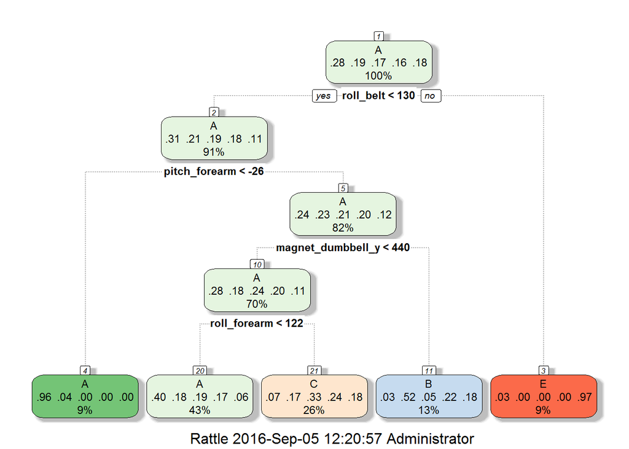

```r
set.seed(200)
rpartTraining <- train(classe ~ ., data = myTrainingData, method = "rpart", trControl = controlParameter)

## Plot the data to see the decision tree
fancyRpartPlot(rpartTraining$finalModel)
```

```r
## Predict using this model and check the overall accuracy
predictionsRPart <- predict(rpartTraining, myTestingData)
matrixRPart <- confusionMatrix(predictionsRPart, myTestingData$classe)
matrixRPart$overall
```

```
##       Accuracy          Kappa  AccuracyLower  AccuracyUpper   AccuracyNull
##      0.4942646      0.3395391      0.4831419      0.5053915      0.2844762
## AccuracyPValue  McnemarPValue
##      0.0000000            NaN
```

#### Decision tree with Random Forest

```r
set.seed(300)
rfTraining <- train(classe ~ ., data = myTrainingData, method = "rf", trControl = controlParameter,
    ntree = 100)
## Predict using this model and check the overall accuracy
predictionsRF <- predict(rfTraining, myTestingData)
matrixRF <- confusionMatrix(predictionsRF, myTestingData$classe)
matrixRF$overall
```

```
##       Accuracy          Kappa  AccuracyLower  AccuracyUpper   AccuracyNull
##      0.9908233      0.9883904      0.9884573      0.9928131      0.2844762
## AccuracyPValue  McnemarPValue
##      0.0000000            NaN
```

#### Decision tree with Gradiant boosting tree (gbm)

```r
set.seed(400)
gbmTraining <- invisible(train(classe ~ ., data = myTrainingData, method = "gbm",
    trControl = controlParameter, verbose = FALSE))

predictionsGbm <- predict(gbmTraining, myTestingData)
matrixGbm <- confusionMatrix(predictionsGbm, myTestingData$classe)
matrixGbm$overall
```

```
##       Accuracy          Kappa  AccuracyLower  AccuracyUpper   AccuracyNull
##   9.616365e-01   9.514568e-01   9.571478e-01   9.657780e-01   2.844762e-01
## AccuracyPValue  McnemarPValue
##   0.000000e+00   1.379862e-05
```

```r
set.seed(500)
rfTraining2 <- train(classe ~ ., data = myTrainingData, method = "rf", trControl = controlParameter,
    ntree = 500)


## Predict using this model and check the overall accuracy
predictionsRF2 <- predict(rfTraining2, myTestingData)
matrixRF2 <- confusionMatrix(predictionsRF2, myTestingData$classe)
matrixRF2$overall
```

```
##       Accuracy          Kappa  AccuracyLower  AccuracyUpper   AccuracyNull
##      0.9910783      0.9887136      0.9887412      0.9930386      0.2844762
## AccuracyPValue  McnemarPValue
##      0.0000000            NaN
```

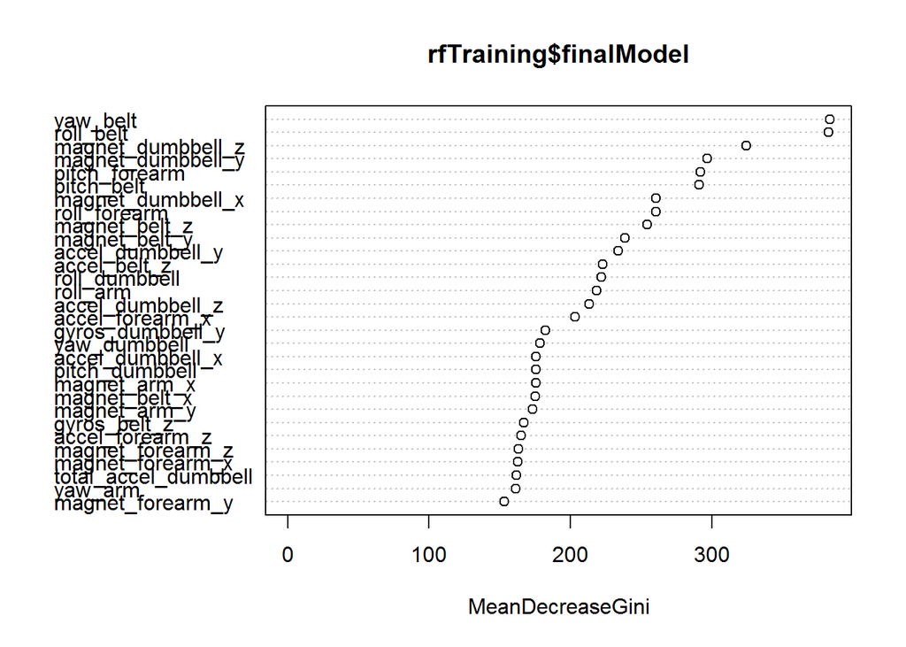

```r
## Plot the predictors used in the order of importance
varImpPlot(rfTraining$finalModel)
```

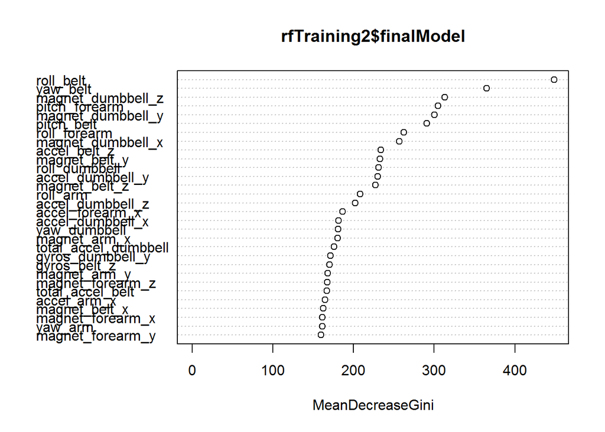

```r
varImpPlot(rfTraining2$finalModel)
```

```r
head(varImp(rfTraining$finalModel), 5)
```

```
##                   Overall
## roll_belt        382.3017
## pitch_belt       290.8176
## yaw_belt         383.2211
## total_accel_belt 148.5266
## gyros_belt_x     108.0312
```

```r
head(varImp(rfTraining2$finalModel), 5)
```

```
##                   Overall
## roll_belt        448.4834
## pitch_belt       290.9871
## yaw_belt         364.9558
## total_accel_belt 166.9034
## gyros_belt_x     104.9749
```

## Out of Sample error

The random forest model with ntree = 500 seems to have the lowest error of 0.0088

## Predictions of the actual testing data

```r
predictionResults <- predict(rfTraining2, origTestingData)
predictionResults
```

```
##  [1] B A B A A E D B A A B C B A E E A B B B
## Levels: A B C D E
```

## Conclusion

For this project data the “Random Forest” decision model based prediction model seems to be the most accurate (by checking the overall accuracy using confusion matrix).